# Case Study: How can a wellness company play it smart?

Famuwagun Olaitan

2/7/2023

## About the company

Bellabeat, a high-tech manufacturer of health-focused products for women. Bellabeat is a successful small company, but they have the potential to become a larger player in the global smart device market. Urška Sršen, cofounder and Chief Creative Officer of Bellabeat, believes that analyzing smart device fitness data could help unlock new growth opportunities for the company. Urška Sršen and Sando Mur founded Bellabeat, a high-tech company that manufactures health-focused smart products. Sršen used her background as an artist to develop beautifully designed technology that informs and inspires women around the world. Collecting data on activity, sleep, stress, and reproductive health has allowed Bellabeat to empower women with knowledge about their own health and habits. Since it was founded in 2013, Bellabeat has grown rapidly and quickly positioned itself as a tech-driven wellness company for women.

## Questions for the analysis

```
1. What are some trends in smart device usage?
2. How could these trends apply to Bellabeat customers?
3. How could these trends help influence Bellabeat marketing strategy
```

## Business task

Identify potential opportunities for growth and recommendations for the Bellabeat marketing strategy improvement based on trends in smart device usage.

## Process Phase:

In this phase we will process the data by cleaning and ensuring that it is correct,relevant,complete and error free.

-We have to check if data contains any missing or null values -Transform the data into format we want for the analysis

## Loading packages

```r
library(tidyverse)
library(lubridate)
```

```r
library(timechange)
library(ggplot2)
library(dplyr)
library(gsubfn)
library(proto)
library(RSQLite)
library(sqldf)
library(plotrix)
library(skimr)
```

## Upload the dataset

The data that is provided is [FitBit Fitness Tracker Data](https://www.kaggle.com/arashnic/fitbit) . This dataset has 18 different csv files that range from Daily activity, calories, steps; hourly calories, intensities, and steps; and heart rate, sleep data and weight logs. After looking at the types of data collected by these 30 fitbit users, i discovered: * No water intake data has been collected

These data may not actually assist me, but that will come with exploration. Load the CSV files The data frames I’ll be working with in this case study will be creating objects for:

- daily_activity
- daily calories
- sleep day
- weight log info
- daily intensities

```r
Daily_Activity <-read.csv("C:\\Users\\LAITAN PC\\Desktop\\case_study2\\Fitabase Data 4.12.16-5.12.16\\dailyActivity_merged.csv")
Sleep_Day <-read.csv("C:\\Users\\LAITAN PC\\Desktop\\case_study2\\Fitabase Data 4.12.16-5.12.16\\sleepDay_merged.csv")
Weight_Log <-read.csv("C:\\Users\\LAITAN PC\\Desktop\\case_study2\\Fitabase Data 4.12.16-5.12.16\\weightLogInfo_merged.csv")
Daily_calories <-read.csv("C:\\Users\\LAITAN PC\\Desktop\\case_study2\\Fitabase Data 4.12.16-5.12.16\\dailyCalories_merged.csv")
Daily_intensities <-read.csv("C:\\Users\\LAITAN PC\\Desktop\\case_study2\\Fitabase Data 4.12.16-5.12.16\\dailyIntensities_merged.csv")
```

## Check and Removing ‘unwanted bad’ data

We need to see if there are any null or missing values in the data. We can check this using the following commands.

```r
str(Daily_Activity)
```

```
## 'data.frame':    940 obs. of  15 variables:
##  $ Id                      : num  1.5e+09 1.5e+09 1.5e+09 1.5e+09 1.5e+09 ...
##  $ ActivityDate            : chr  "4/12/2016" "4/13/2016" "4/14/2016" "4/15/2016" ...
##  $ TotalSteps              : int  13162 10735 10460 9762 12669 9705 13019 15506 10544 9819 ...
##  $ TotalDistance           : num  8.5 6.97 6.74 6.28 8.16 ...
##  $ TrackerDistance         : num  8.5 6.97 6.74 6.28 8.16 ...
##  $ LoggedActivitiesDistance: num  0 0 0 0 0 0 0 0 0 0 ...
##  $ VeryActiveDistance      : num  1.88 1.57 2.44 2.14 2.71 ...
##  $ ModeratelyActiveDistance: num  0.55 0.69 0.4 1.26 0.41 ...
##  $ LightActiveDistance     : num  6.06 4.71 3.91 2.83 5.04 ...
##  $ SedentaryActiveDistance : num  0 0 0 0 0 0 0 0 0 0 ...
##  $ VeryActiveMinutes       : int  25 21 30 29 36 38 42 50 28 19 ...
##  $ FairlyActiveMinutes     : int  13 19 11 34 10 20 16 31 12 8 ...
##  $ LightlyActiveMinutes    : int  328 217 181 209 221 164 233 264 205 211 ...
##  $ SedentaryMinutes        : int  728 776 1218 726 773 539 1149 775 818 838 ...
##  $ Calories                : int  1985 1797 1776 1745 1863 1728 1921 2035 1786 1775 ...
```

```r
skim(Daily_Activity)
```

Data summary

| Name | Daily_Activity |
| --- | --- |
| Number of rows | 940 |
| Number of columns | 15 |
| _______________________ |  |
| Column type frequency: |  |
| character | 1 |
| numeric | 14 |
| ________________________ |  |
| Group variables | None |

**Variable type: character**

| skim_variable | n_missing | complete_rate | min | max | empty | n_unique | whitespace |
| --- | --- | --- | --- | --- | --- | --- | --- |
| ActivityDate | 0 | 1 | 8 | 9 | 0 | 31 | 0 |

**Variable type: numeric**

| skim_variable | n_missing | complete_rate | mean | sd | p0 | p25 | p50 | p75 | p100 | hist |
| --- | --- | --- | --- | --- | --- | --- | --- | --- | --- | --- |
| Id | 0 | 1 | 4.855407e+09 | 2.424805e+09 | 1503960366 | 2.320127e+09 | 4.445115e+09 | 6.962181e+09 | 8.877689e+09 | ▇▅▃▅▅ |
| TotalSteps | 0 | 1 | 7.637910e+03 | 5.087150e+03 | 0 | 3.789750e+03 | 7.405500e+03 | 1.072700e+04 | 3.601900e+04 | ▇▇▁▁▁ |
| TotalDistance | 0 | 1 | 5.490000e+00 | 3.920000e+00 | 0 | 2.620000e+00 | 5.240000e+00 | 7.710000e+00 | 2.803000e+01 | ▇▆▁▁▁ |
| TrackerDistance | 0 | 1 | 5.480000e+00 | 3.910000e+00 | 0 | 2.620000e+00 | 5.240000e+00 | 7.710000e+00 | 2.803000e+01 | ▇▆▁▁▁ |
| LoggedActivitiesDistance | 0 | 1 | 1.100000e-01 | 6.200000e-01 | 0 | 0.000000e+00 | 0.000000e+00 | 0.000000e+00 | 4.940000e+00 | ▇▁▁▁▁ |
| VeryActiveDistance | 0 | 1 | 1.500000e+00 | 2.660000e+00 | 0 | 0.000000e+00 | 2.100000e-01 | 2.050000e+00 | 2.192000e+01 | ▇▁▁▁▁ |
| ModeratelyActiveDistance | 0 | 1 | 5.700000e-01 | 8.800000e-01 | 0 | 0.000000e+00 | 2.400000e-01 | 8.000000e-01 | 6.480000e+00 | ▇▁▁▁▁ |
| LightActiveDistance | 0 | 1 | 3.340000e+00 | 2.040000e+00 | 0 | 1.950000e+00 | 3.360000e+00 | 4.780000e+00 | 1.071000e+01 | ▆▇▆▁▁ |
| SedentaryActiveDistance | 0 | 1 | 0.000000e+00 | 1.000000e-02 | 0 | 0.000000e+00 | 0.000000e+00 | 0.000000e+00 | 1.100000e-01 | ▇▁▁▁▁ |
| VeryActiveMinutes | 0 | 1 | 2.116000e+01 | 3.284000e+01 | 0 | 0.000000e+00 | 4.000000e+00 | 3.200000e+01 | 2.100000e+02 | ▇▁▁▁▁ |
| FairlyActiveMinutes | 0 | 1 | 1.356000e+01 | 1.999000e+01 | 0 | 0.000000e+00 | 6.000000e+00 | 1.900000e+01 | 1.430000e+02 | ▇▁▁▁▁ |
| LightlyActiveMinutes | 0 | 1 | 1.928100e+02 | 1.091700e+02 | 0 | 1.270000e+02 | 1.990000e+02 | 2.640000e+02 | 5.180000e+02 | ▅▇▇▃▁ |
| SedentaryMinutes | 0 | 1 | 9.912100e+02 | 3.012700e+02 | 0 | 7.297500e+02 | 1.057500e+03 | 1.229500e+03 | 1.440000e+03 | ▁▁▇▅▇ |
| Calories | 0 | 1 | 2.303610e+03 | 7.181700e+02 | 0 | 1.828500e+03 | 2.134000e+03 | 2.793250e+03 | 4.900000e+03 | ▁▆▇▃▁ |

```r
head(Sleep_Day)
```

```
##           Id              SleepDay TotalSleepRecords TotalMinutesAsleep
## 1 1503960366 4/12/2016 12:00:00 AM                 1                327
## 2 1503960366 4/13/2016 12:00:00 AM                 2                384
## 3 1503960366 4/15/2016 12:00:00 AM                 1                412
## 4 1503960366 4/16/2016 12:00:00 AM                 2                340
## 5 1503960366 4/17/2016 12:00:00 AM                 1                700
## 6 1503960366 4/19/2016 12:00:00 AM                 1                304
##   TotalTimeInBed
## 1            346
## 2            407
## 3            442
## 4            367
## 5            712
## 6            320
```

```r
str(Weight_Log)
```

```
## 'data.frame':    67 obs. of  8 variables:
##  $ Id            : num  1.50e+09 1.50e+09 1.93e+09 2.87e+09 2.87e+09 ...
##  $ Date          : chr  "5/2/2016 11:59:59 PM" "5/3/2016 11:59:59 PM" "4/13/2016 1:08:52 AM" "4/21/2016 11:59:59 PM" ...
##  $ WeightKg      : num  52.6 52.6 133.5 56.7 57.3 ...
##  $ WeightPounds  : num  116 116 294 125 126 ...
##  $ Fat           : int  22 NA NA NA NA 25 NA NA NA NA ...
##  $ BMI           : num  22.6 22.6 47.5 21.5 21.7 ...
##  $ IsManualReport: chr  "True" "True" "False" "True" ...
##  $ LogId         : num  1.46e+12 1.46e+12 1.46e+12 1.46e+12 1.46e+12 ...
```

```r
skim(Weight_Log)
```

Data summary

| Name | Weight_Log |
| --- | --- |
| Number of rows | 67 |
| Number of columns | 8 |
| _______________________ |  |
| Column type frequency: |  |
| character | 2 |
| numeric | 6 |
| ________________________ |  |
| Group variables | None |

**Variable type: character**

| skim_variable | n_missing | complete_rate | min | max | empty | n_unique | whitespace |
| --- | --- | --- | --- | --- | --- | --- | --- |
| Date | 0 | 1 | 19 | 21 | 0 | 56 | 0 |
| IsManualReport | 0 | 1 | 4 | 5 | 0 | 2 | 0 |

**Variable type: numeric**

| skim_variable | n_missing | complete_rate | mean | sd | p0 | p25 | p50 | p75 | p100 | hist |
| --- | --- | --- | --- | --- | --- | --- | --- | --- | --- | --- |
| Id | 0 | 1.00 | 7.009282e+09 | 1.950322e+09 | 1.503960e+09 | 6.962181e+09 | 6.962181e+09 | 8.877689e+09 | 8.877689e+09 | ▁▁▂▇▆ |
| WeightKg | 0 | 1.00 | 7.204000e+01 | 1.392000e+01 | 5.260000e+01 | 6.140000e+01 | 6.250000e+01 | 8.505000e+01 | 1.335000e+02 | ▇▃▃▁▁ |
| WeightPounds | 0 | 1.00 | 1.588100e+02 | 3.070000e+01 | 1.159600e+02 | 1.353600e+02 | 1.377900e+02 | 1.875000e+02 | 2.943200e+02 | ▇▃▃▁▁ |
| Fat | 65 | 0.03 | 2.350000e+01 | 2.120000e+00 | 2.200000e+01 | 2.275000e+01 | 2.350000e+01 | 2.425000e+01 | 2.500000e+01 | ▇▁▁▁▇ |
| BMI | 0 | 1.00 | 2.519000e+01 | 3.070000e+00 | 2.145000e+01 | 2.396000e+01 | 2.439000e+01 | 2.556000e+01 | 4.754000e+01 | ▇▁▁▁▁ |
| LogId | 0 | 1.00 | 1.461772e+12 | 7.829948e+08 | 1.460444e+12 | 1.461079e+12 | 1.461802e+12 | 1.462375e+12 | 1.463098e+12 | ▇▇▆▇▇ |

```r
head(Weight_Log)
```

```
##           Id                  Date WeightKg WeightPounds Fat   BMI
## 1 1503960366  5/2/2016 11:59:59 PM     52.6     115.9631  22 22.65
## 2 1503960366  5/3/2016 11:59:59 PM     52.6     115.9631  NA 22.65
## 3 1927972279  4/13/2016 1:08:52 AM    133.5     294.3171  NA 47.54
## 4 2873212765 4/21/2016 11:59:59 PM     56.7     125.0021  NA 21.45
## 5 2873212765 5/12/2016 11:59:59 PM     57.3     126.3249  NA 21.69
## 6 4319703577 4/17/2016 11:59:59 PM     72.4     159.6147  25 27.45
##   IsManualReport        LogId
## 1           True 1.462234e+12
## 2           True 1.462320e+12
## 3          False 1.460510e+12
## 4           True 1.461283e+12
## 5           True 1.463098e+12
## 6           True 1.460938e+12
```

## After executing these commands we found out the:

- Number of records and columns
- Number of null and non null values
- Data type of every columns

```r
Daily_Activity$Rec_Date <- as.Date(Daily_Activity$ActivityDate,"%m/%d/%y")
Daily_Activity$month <- format(Daily_Activity$Rec_Date,"%B")
Daily_Activity$day_of_week <- format(Daily_Activity$Rec_Date,"%A")
```

```r
n_distinct(Daily_Activity$Id)
```

```
## [1] 33
```

There are 33 unique IDs, instead of 30 unique IDs as expected. Some users may have created additional IDs during the survey period.

Now the **data cleaning** and **manipulation** is done.Now data is ready to be analyzed.

## **Analyze Phase:**

## Let prepare the manipulated data for proper analysis

Now, we need to summarize the data. So that we can derive insights from the ready clean data to help drive decision making.

**To do:**

- Find the suammry of **Daily_activity** and **Weight_log**

```r
Daily_Activity %>%  select(TotalSteps,TotalDistance,SedentaryMinutes,    VeryActiveMinutes) %>% summary()
```

```
##    TotalSteps    TotalDistance    SedentaryMinutes VeryActiveMinutes
##  Min.   :    0   Min.   : 0.000   Min.   :   0.0   Min.   :  0.00
##  1st Qu.: 3790   1st Qu.: 2.620   1st Qu.: 729.8   1st Qu.:  0.00
##  Median : 7406   Median : 5.245   Median :1057.5   Median :  4.00
##  Mean   : 7638   Mean   : 5.490   Mean   : 991.2   Mean   : 21.16
##  3rd Qu.:10727   3rd Qu.: 7.713   3rd Qu.:1229.5   3rd Qu.: 32.00
##  Max.   :36019   Max.   :28.030   Max.   :1440.0   Max.   :210.00
```

```r
Weight_Log%>%  select(WeightKg,BMI) %>% summary()
```

```
##     WeightKg           BMI
##  Min.   : 52.60   Min.   :21.45
##  1st Qu.: 61.40   1st Qu.:23.96
##  Median : 62.50   Median :24.39
##  Mean   : 72.04   Mean   :25.19
##  3rd Qu.: 85.05   3rd Qu.:25.56
##  Max.   :133.50   Max.   :47.54
```

## **Statistical interpretation:**

1.**Findings from Daily Activity data:**

- The average count of recorded steps is 7638 which is less than recommended 10000 steps and average of total distance covered is 5.490 km which is also less than recommended 8 km mark.
- The average sedentary minutes is 991.2 minutes or 16.52 hours which is very high as it should be at most 7 hours.Even if you are doing enough physical activity, sitting for more than 7 to 10 hours a day is bad for your health. (source: HealthyWA article).
- The average of very active minutes is 21.16 which is less than target of 30 minutes per day. (source:verywell fit)

2.**Findings from weight log:**

- We can not conclude healthiness of person just by knowing there weight, There are other factors like height,fat percentage affect in the health.
- The average of BMI is 25.19 which is slightly grater than the healthy BMI range which is between 18 and 24.9.

```r
Avg_minutes_asleep <- sqldf("SELECT SUM(TotalSleepRecords),SUM(TotalMinutesAsleep)/SUM(TotalSleepRecords) as avg_sleeptime
                            FROM Sleep_Day")
Avg_minutes_asleep
```

```
##   SUM(TotalSleepRecords) avg_sleeptime
## 1                    462           374
```

```r
Avg_TimeInBed <- sqldf("SELECT SUM(TotalTimeInBed)/SUM(TotalSleepRecords) as avg_timeInBed
                       FROM Sleep_Day")

Avg_TimeInBed
```

```
##   avg_timeInBed
## 1           409
```

```r
n_distinct(Sleep_Day$Id)
```

```
## [1] 24
```

## **Share Phase:** Data visualizations

In this step, we will create some **visualizations** based on our **analysis** and **goal** of project.

## Let check and count the activity by the week days

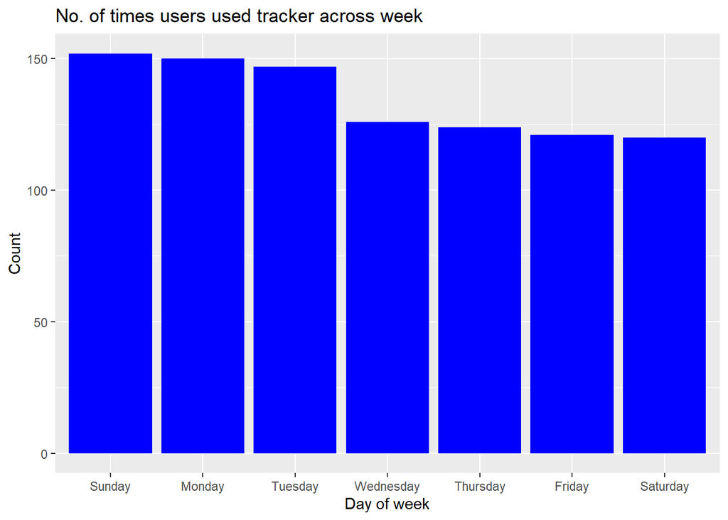

```r
Daily_Activity$day_of_week <- ordered(Daily_Activity$day_of_week,levels=c("Sunday","Monday","Tuesday","Wednesday","Thursday","Friday","Saturday"))

ggplot(data=Daily_Activity) + geom_bar(mapping = aes(x=day_of_week),fill="blue") +
  labs(x="Day of week",y="Count",title="No. of times users used tracker across week")
```

## Let correlate the daily_step with the total_calories burns.

```r
mean_steps <- mean(Daily_Activity$TotalSteps)
mean_steps
```

```
## [1] 7637.911
```

- the output show that average steps per days tracked using FitBit Application is **7637.911**

```r
mean_calories <- mean(Daily_Activity$Calories)
mean_calories
```

```
## [1] 2303.61
```

- the output show that average calories burnt per days as tracked using FitBit Application is **2303.61**

```r
Avg_Calories_burn_per_step_taken <-mean_steps/mean_calories
Avg_Calories_burn_per_step_taken
```

```
## [1] 3.315627
```

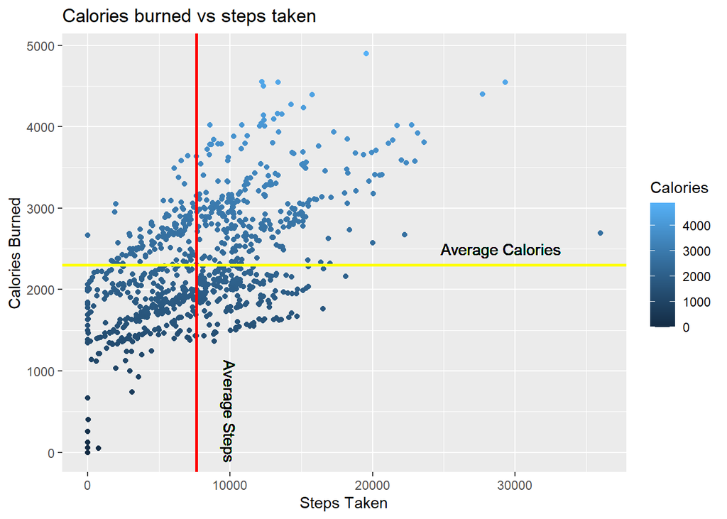

```r
ggplot(data=Daily_Activity) + geom_point(mapping=aes(x=TotalSteps, y=Calories, color=Calories)) +
geom_hline(mapping = aes(yintercept=mean_calories),color="yellow",lwd=1.0) +
  geom_vline(mapping = aes(xintercept=mean_steps),color="red",lwd=1.0) +
  geom_text(mapping = aes(x=10000,y=500,label="Average Steps",srt=-90)) +
  geom_text(mapping = aes(x=29000,y=2500,label="Average Calories")) +
  labs(x="Steps Taken",y="Calories Burned",title = "Calories burned vs steps taken")
```

## Calories burned for every step taken

- It is a positive correlation with some outliers at bottom and top of scatter plot.
- It is clear from the plot that intensity of calories burned increase with number of steps taken. ## Let compare the total steps taken with Sedentary Minutes

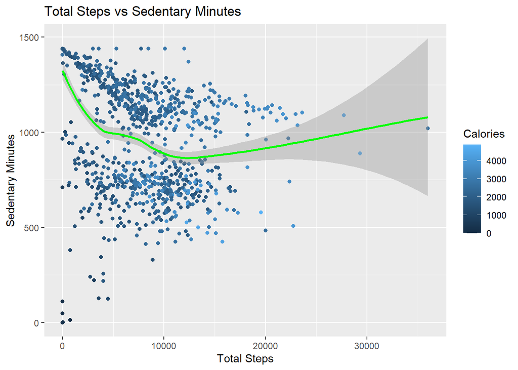

```r
ggplot(data=Daily_Activity, aes(x=TotalSteps, y=SedentaryMinutes, color = Calories)) + geom_point() +
geom_smooth(method = "loess",color="green") +
labs(x="Total Steps",y="Sedentary Minutes",title="Total Steps vs Sedentary Minutes")
```

## Total steps taken vs sedentary minutes

I was expecting a totally inverse relationship between steps taken and sedentary minutes.

- At the start when the steps taken are less than 10000 the relation between them is inverse, but as number of steps increases beyond 10000 there is no drastic change in relation.
- I got surprised watching the relation between steps and sedentary minutes after 15000 steps as it becomes slightly positive.

## Let compare the sleeps time with the time in beds

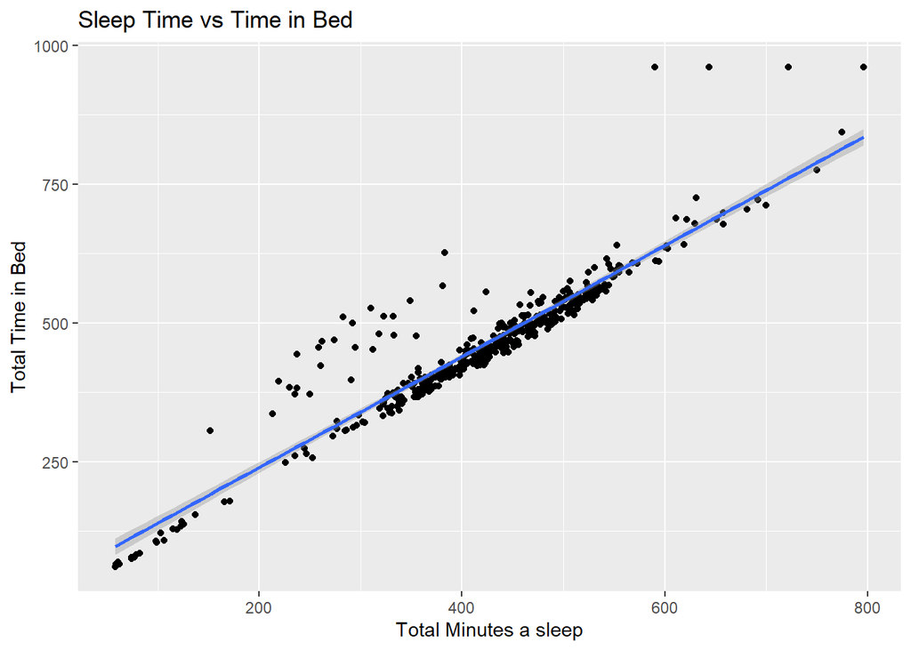

```r
ggplot(data=Sleep_Day, aes(x=TotalMinutesAsleep, y=TotalTimeInBed)) + geom_point() + stat_smooth(method = lm) +
  labs(x="Total Minutes a sleep", y="Total Time in Bed", title = "Sleep Time vs Time in Bed")
```

## Relation between sleep and time in bed

- As we can see, there is a strong positive correlation between TotalMinutesAsleep and TotalTimeInBed, but there are some outliers in data in the middle and top of plot.
- The outliers are one who spend lot of time in bed but didn’t actually sleep.There can be different reasons for that.

## Let compare the Active minutes with the calories burn

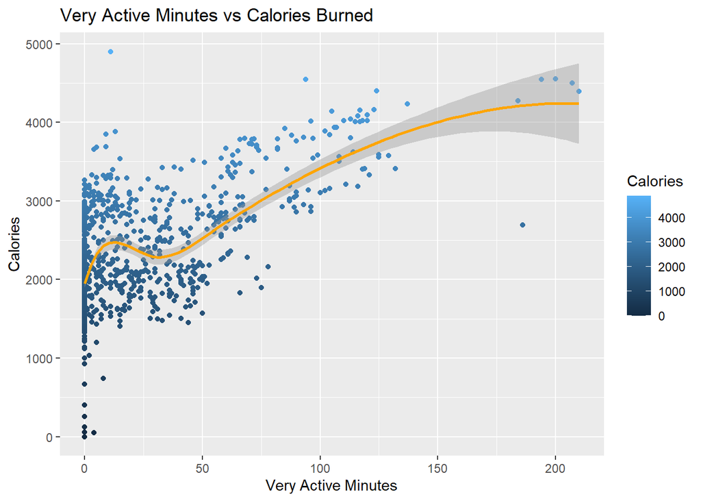

```r
ggplot(data=Daily_Activity,aes(x = VeryActiveMinutes, y = Calories, color = Calories)) + geom_point() +
geom_smooth(method = "loess",color="orange") +
labs(x="Very Active Minutes",y="Calories",title = "Very Active Minutes vs Calories Burned")
```

## Relation between very active minutes and calories burned

- As we can see,very active minutes and calories burned are highly correlated with each other with some outliers at bottom left and top left of the plot.

## Let compare the sedentary minutes with the calories burned

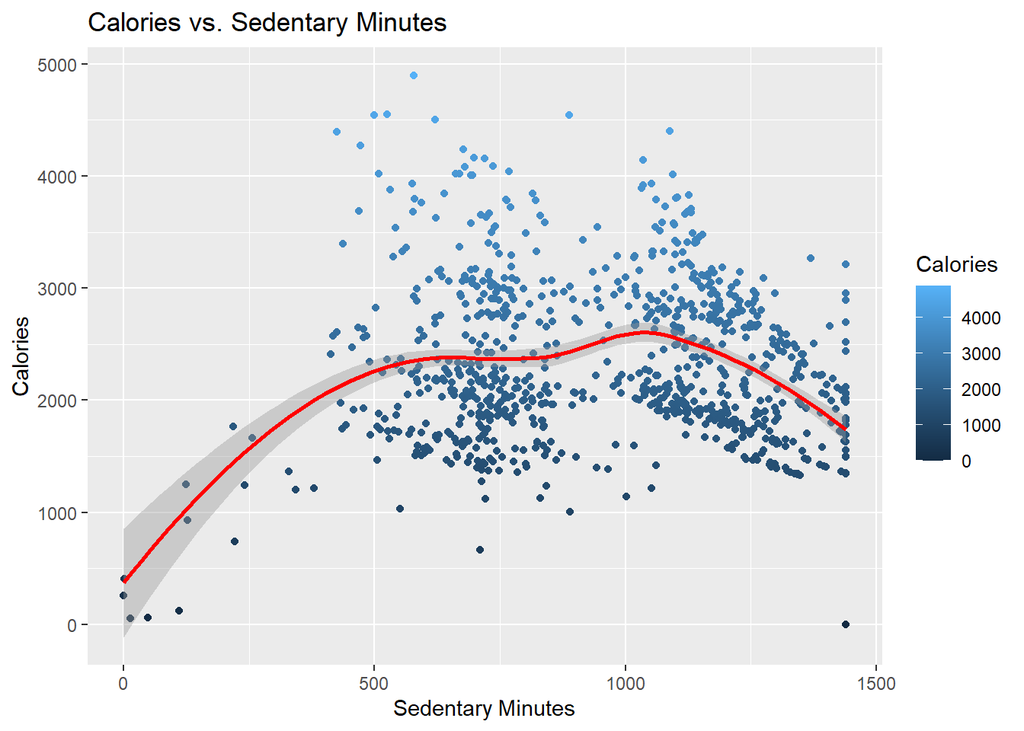

```r
ggplot(data=Daily_Activity,aes(x=SedentaryMinutes,y=Calories,color=Calories)) + geom_point() +
geom_smooth(method="loess",color="red") +
labs(y="Calories", x="Sedentary Minutes", title="Calories vs. Sedentary Minutes")
```

## Relation between sedentary minutes and calories burned:

I was expecting the relation between sedentary minutes and calories burned to be totally inverse in nature.

- The data is showing positive correlation up to 1000 sedentary minutes.
- After 1000 sedentary minutes the relation is inverse as I expected.

## Now,we will calculate the sum of individual minute column from daily activity data

This visualization will show the relationships between minutes in Daily Activity for proper data correlation

```r
activity_min <- sqldf("SELECT SUM(VeryActiveMinutes),SUM(FairlyActiveMinutes),
      SUM(LightlyActiveMinutes),SUM(SedentaryMinutes)
      FROM Daily_Activity")
activity_min
```

```
##   SUM(VeryActiveMinutes) SUM(FairlyActiveMinutes) SUM(LightlyActiveMinutes)
## 1                  19895                    12751                    181244
##   SUM(SedentaryMinutes)
## 1                931738
```

As we got the values, we will use these values to plot a 3D pie chart to compare the percentage of activity by minutes.

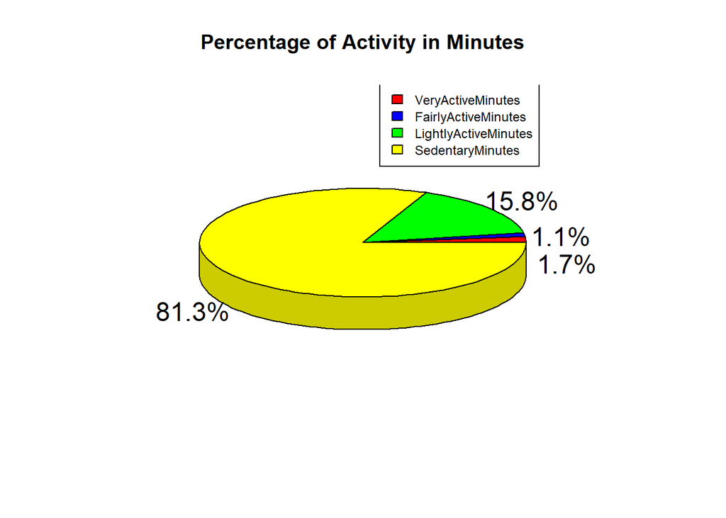

```r
x <- c(19895,12751,181244,931738)
piepercent <- round(100*x / sum(x), 1)
colors = c("red","blue","green","yellow")

pie3D(x,labels = paste0(piepercent,"%"),col = colors,main = "Percentage of Activity in Minutes")
legend("topright",c("VeryActiveMinutes","FairlyActiveMinutes","LightlyActiveMinutes","SedentaryMinutes"), cex=0.75, fill = colors)
```

## Percentage of activity in Minutes:

As we can see,

- The percentage of sedentary minutes is very high than all other,which covers 81.3 % of pie this indicates that people are inactive for longer period of time.
- The percentage of very active and fairly active minutes is very less ie. 1.7%,1.1% respectively,which is very less compared to other activities.

Now, we will calculate sum of different distance values from daily activity data:

```r
Activity_dist <- sqldf("SELECT SUM(ModeratelyActiveDistance),SUM(LightActiveDistance),
      SUM(VeryActiveDistance),SUM(SedentaryActiveDistance)
      FROM Daily_Activity")
Activity_dist
```

```
##   SUM(ModeratelyActiveDistance) SUM(LightActiveDistance)
## 1                        533.49                  3140.37
##   SUM(VeryActiveDistance) SUM(SedentaryActiveDistance)
## 1                 1412.52                         1.51
```

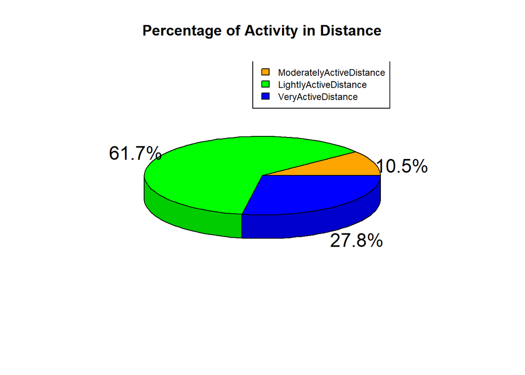

```r
y <- c(533.49,3140.37,1412.52)

piepercent <- round(100*y / sum(y), 1)
colors = c("orange","green","blue")
pie3D(y,labels = paste0(piepercent,"%"),col=colors,main = "Percentage of Activity in Distance")
legend("topright",c("ModeratelyActiveDistance","LightlyActiveDistance","VeryActiveDistance"),cex=0.75,fill = colors)
```

## Percentage of activity in distance:

As we can see,

- The percentage of lightly active distance is highest with 61.7% and that of moderately active distance is 10.5%.
- The percentage of very active distance is 27.8% which is good, but it can be increased further so that people can achieve there fitness goals.

Now, we will calculate the count of people with over weight: The BMI for healthy person is between 18.5 and 24.9 and the persons who’s BMI is above 24.9 are considered to be overweight.(source:CDC)

```r
count_overweight <- sqldf("SELECT COUNT(DISTINCT(Id))
                          FROM Weight_Log
                          WHERE BMI > 24.9")
count_overweight
```

```
##   COUNT(DISTINCT(Id))
## 1                   5
```

As we got the values, we will use these values to plot a 3D pie chart to compare the percentage of people with overweight vs healthy weight.

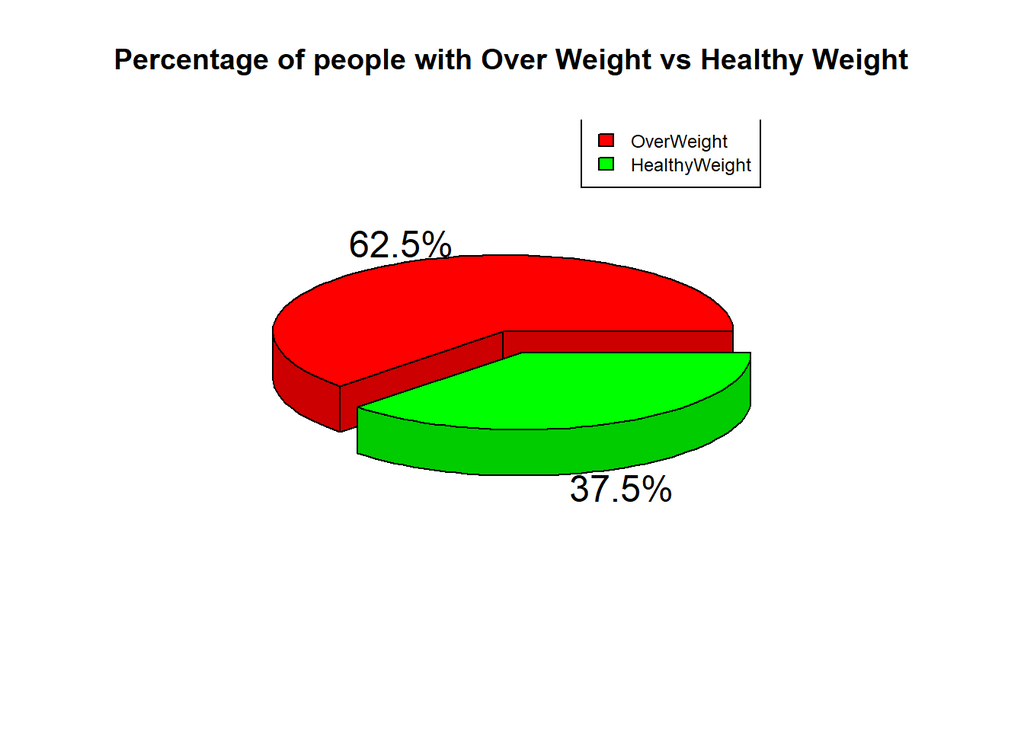

```r
z <- c(5,3)
piepercent <- round(100*z / sum(z),1)
colors = c("red","green")
pie3D(z,labels=paste0(piepercent,"%"),explode=0.1,col=colors,radius=1,main="Percentage of people with Over Weight vs Healthy Weight")
legend("topright",c("OverWeight","HealthyWeight"), cex=0.75,fill=colors)
```

We have less number of records,but we can see:

- The percentage of people with over weight is 62.5% which is high as compared to percentage of people with healthy weight which is 37.5%. So, there is a very good opportunity to increase the percentage of people with healthy weight.

## Act Phase:

The goal of analysis is correct as we got many useful insights from the FitBit data,which will help us to make data driven decision. Both companies develop similar kind of products.So,the common trends surrounding health and fitness can also be applied to Bellabeat customers.

## Based on the result and analysis we make the following recommendations:

**1.** We have analyzed that most of the people use application to track the steps and calories burned;less number of people use it to track sleep and very few use it to track weight records.So, I will suggest to focus on step,calories and sleep tracking more in application.

**3.** The relation between steps taken vs calories burned and very active minutes vs calories burned shows positive correlation.So, this can be a good marketing strategy.

**6**. Bellabeat marketing team can encourage users by educating and equipping their potential customers with knowledge about fitness benefits, suggest different types of exercises, calories intake and burn rate information on Bellabeat application.